# Tug1 KO vs WT (Adult)

# Design Overview

This file shows the wt-v-ko comparison for Tug1.

Cuff overview:

```
## CuffSet instance with:
##   2 samples
##   26754 genes
##   77524 isoforms
##   0 TSS
##   23066 CDS
##   0 promoters
##   0 splicing
##   19954 relCDS
```

# QC

## Dispersion

Dispersion plot for genes in cuff: (Overdispersion can lead to innacurate quants)

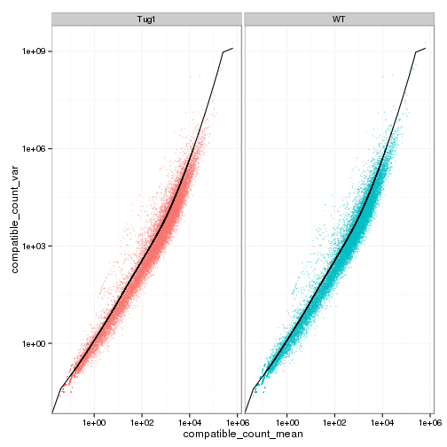

## Cross-replicate variability (fpkmSCVplot)

Differences in CV 2 can result in lower numbers of differentially expressed genes due to a higher degree of variability between replicate fpkm estimates.

Genes:

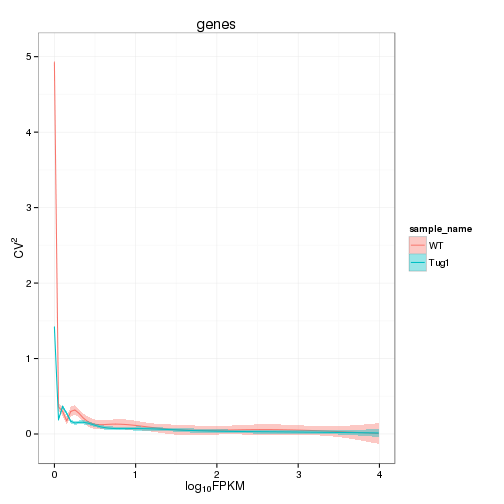

Isoforms:

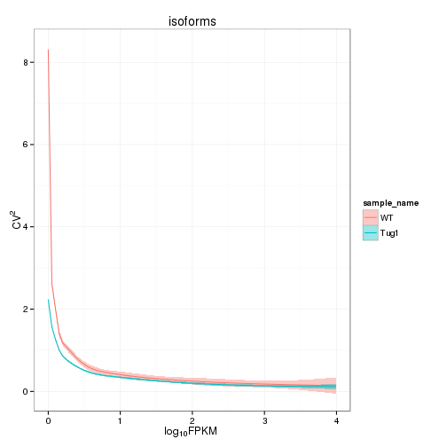

## MvA plot

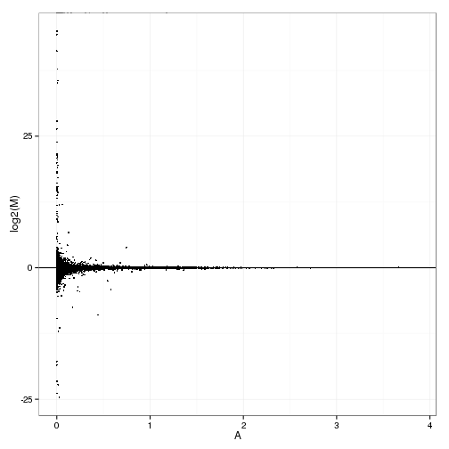

### MvA plot counts

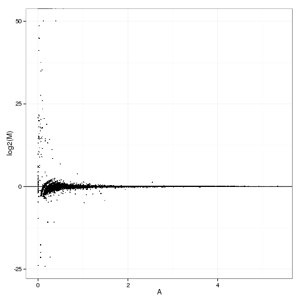

## Scatterplot matrix

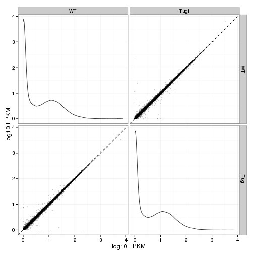

## Distributions

### Boxplots

Boxplot (genes)

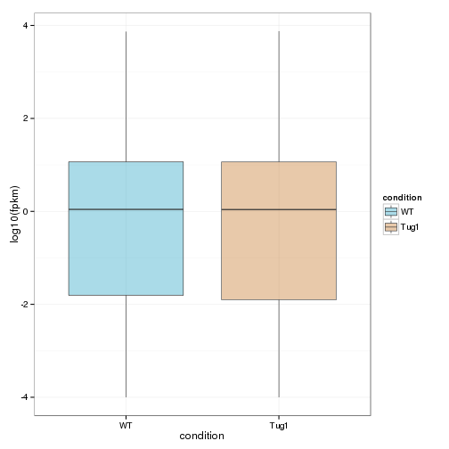

Boxplot (genes, replicates)

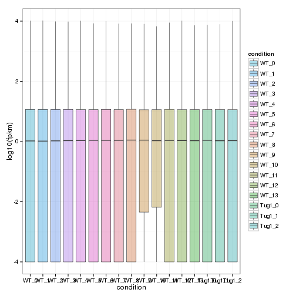

Boxplot (isoforms)

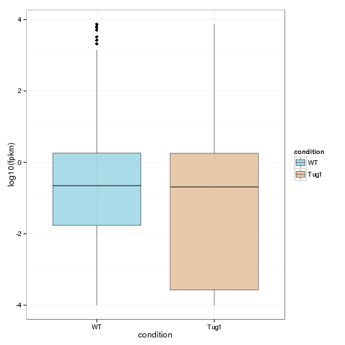

Boxplot (isoforms, replicates)

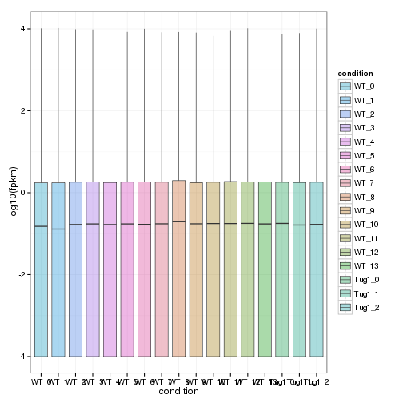

### Density

Density (genes)

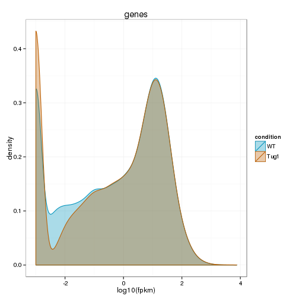

Density (genes, replicates)

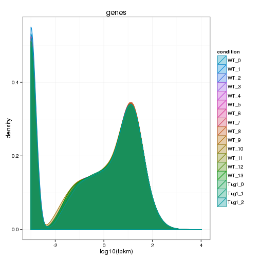

## Clustering

### Replicate Clusters

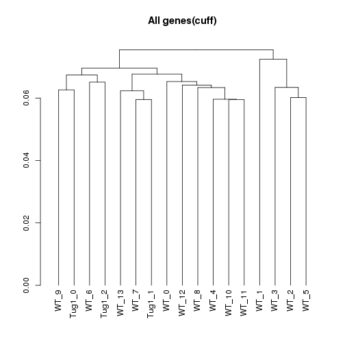

### PCA (genes)

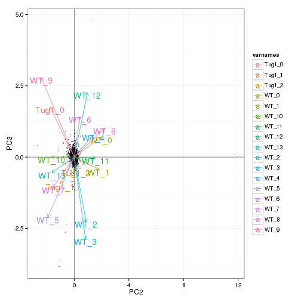

### MDS (genes)

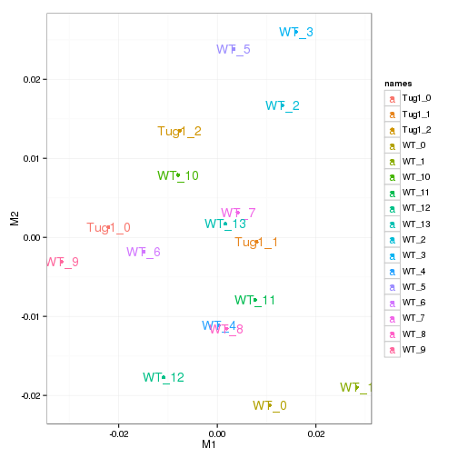

# KO assessment

## Endogenous lncRNA expression

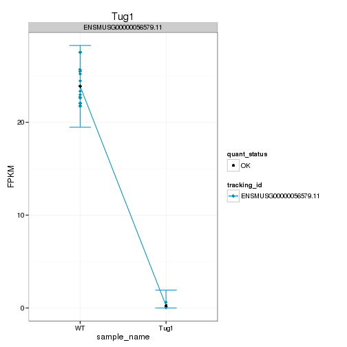

Endogenous expression of Tug1 isoforms:

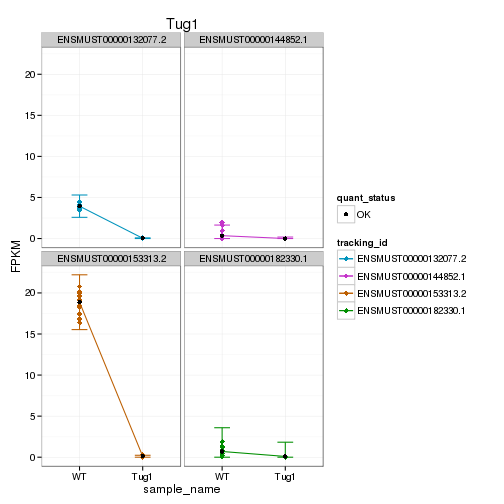

Barplot of gene expression:

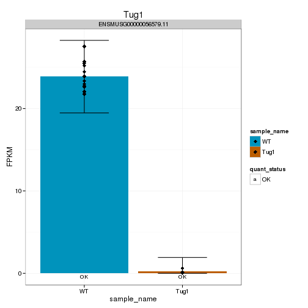

Barplot of isoform expression:

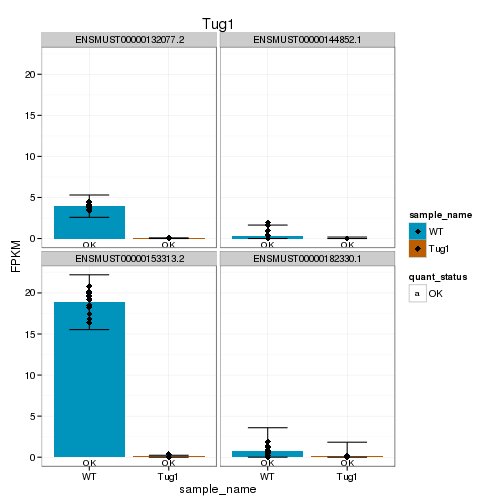

## LacZ expression

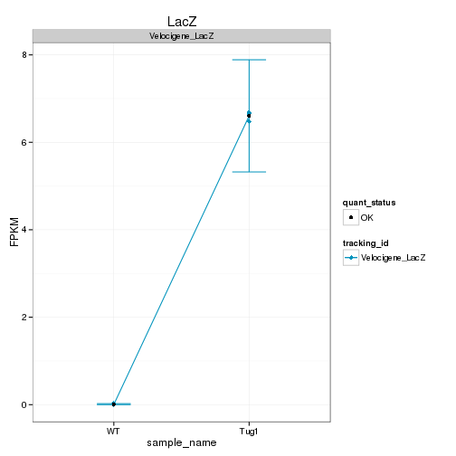

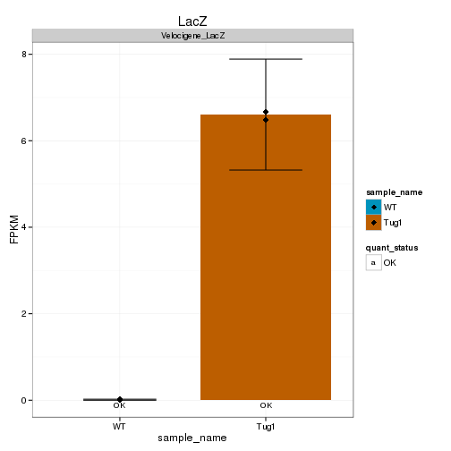

## Digital Genotyping (LacZ vs Endogenous lncRNA and Sex)

Expression plot (endogenous linc, lacZ, Y-expressed gene):

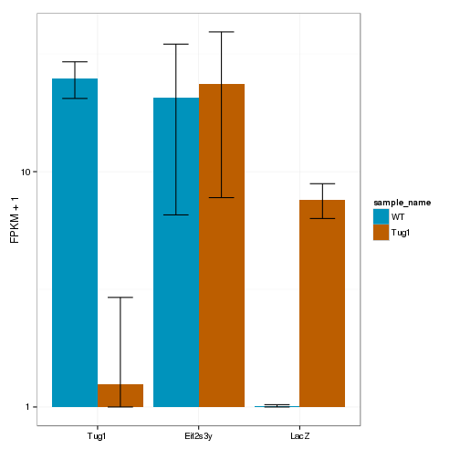

Expression heatmap:

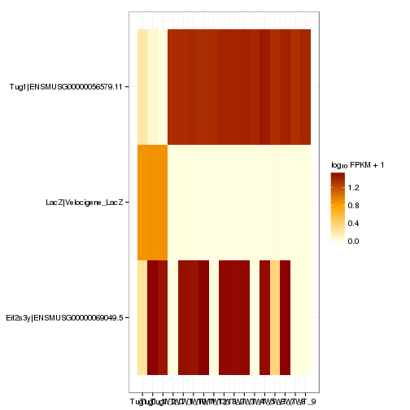

### Track visualization

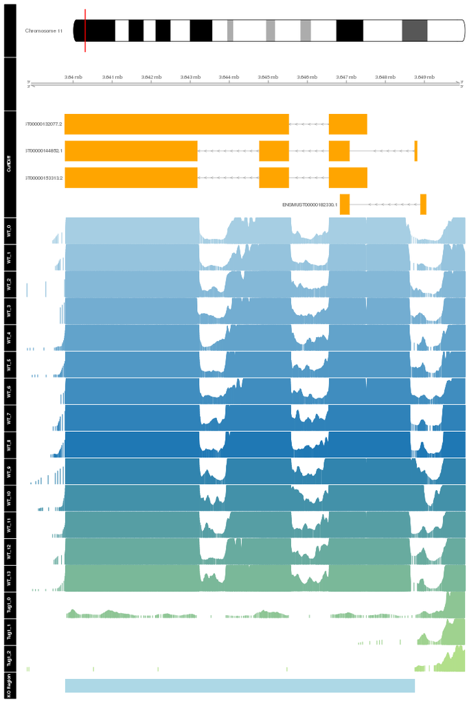

# Differential Analysis

## Differential Genes

There are 65 significantly differentially expressed genes. They are:

|  | geneAnnot$gene_short_name |
| --- | --- |
| 1 | Gabra2 |
| 2 | Ppp1r17 |
| 3 | Cd36 |
| 4 | Pde1c |
| 5 | Nes |
| 6 | Odc1 |
| 7 | 6330403K07Rik |
| 8 | Pdk4 |
| 9 | Gabra6 |
| 10 | Rnf185 |
| 11 | Adi1 |
| 12 | Serpina3n |
| 13 | Arc |
| 14 | Adamts1 |
| 15 | Glo1 |
| 16 | Cyp2e1 |
| 17 | Myoc |
| 18 | Ermn |
| 19 | Car3 |
| 20 | Cyr61 |
| 21 | Padi2 |
| 22 | Ugt2a1 |
| 23 | Herc6 |
| 24 | Hddc3 |
| 25 | Dis3l |
| 26 | Ugt8a |
| 27 | Ndn |
| 28 | Arhgap27 |
| 29 | Morc2a |
| 30 | Inpp5j |
| 31 | Pla2g3 |
| 32 | 8430429K09Rik |
| 33 | Anln |
| 34 | Akap12 |
| 35 | Tspyl5 |
| 36 | Pcsk1n |
| 37 | Cbln3 |
| 38 | C1qtnf4 |
| 39 | Pyurf |
| 40 | Lor |
| 41 | Pcdhb14 |
| 42 | Nhlrc1 |
| 43 | Gm9493 |
| 44 | Rps2 |
| 45 | Acp1 |
| 46 | Npas4 |
| 47 | Fbll1 |
| 48 | Utp18 |
| 49 | Fat2 |
| 50 | Tug1 |
| 51 | Tpt1 |
| 52 | Cfd |
| 53 | Rpl17 |
| 54 | Rps4y2 |
| 55 | Jund |
| 56 | Ppia |
| 57 | Gm9008 |
| 58 | 3222401L13Rik |
| 59 | Selm |
| 60 | Gm14418 |
| 61 | Apold1 |
| 62 | Lrrc32 |
| 63 | AA465934 |
| 64 | Gm14403 |
| 65 | Gm26924 |

### Matrix of gene significant differences between conditions

(skip for Brainmap wt-v-ko comparisons)

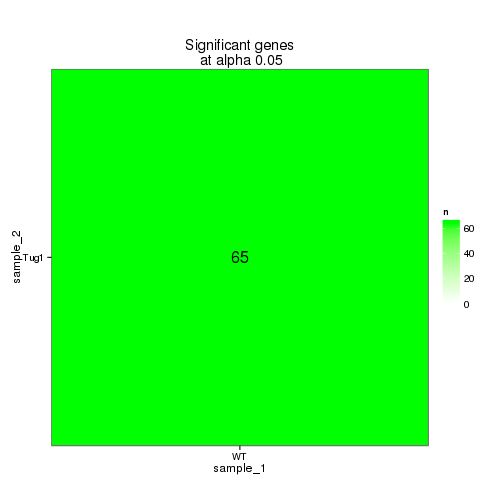

### Significant gene expression differences between conditions

Expression plot (genes):

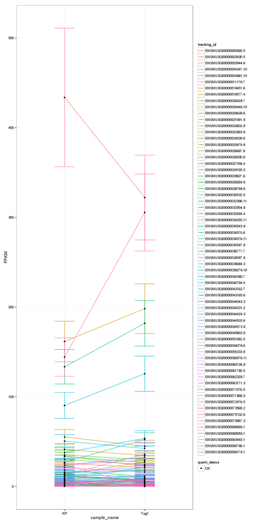

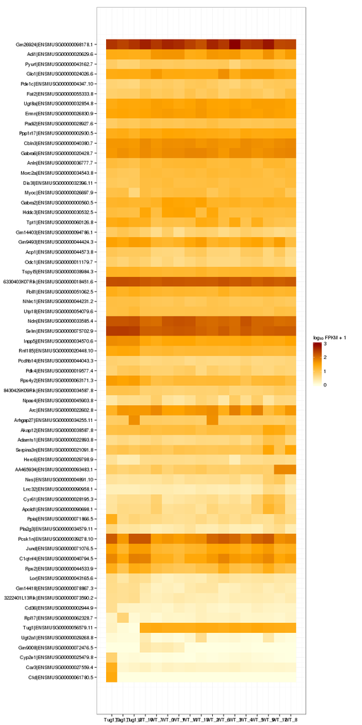

Significant genes with expression >50fpkm (any condition):

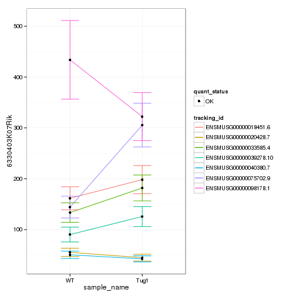

An individual look at each of the highly expressed significantly differentially regulated genes: (eval=false for first pass)

### Expression-level/significance relationship

Scatter plot of significant genes only:

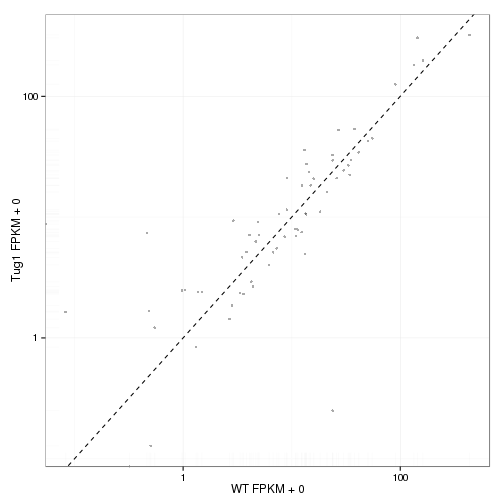

Volcano Plot

Volcano plot with significant genes only:

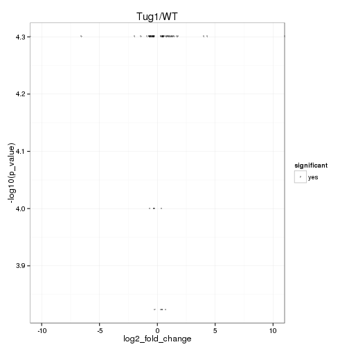

FoldChange Heatmap

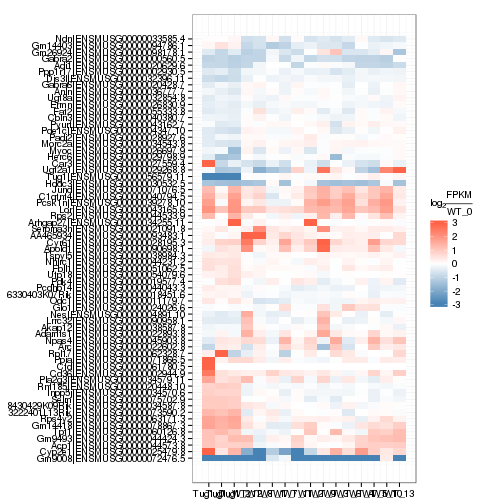

## Differential Splicing

### Differential Isoforms between conditions

Per isoform difference between conditions:

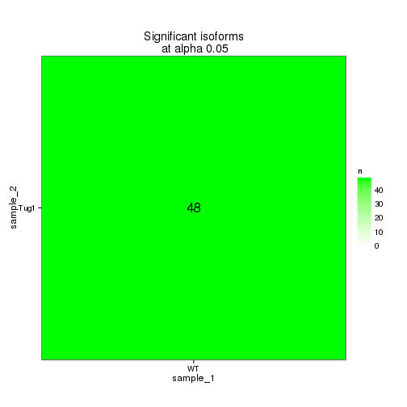

These isoforms are:

|  | isoAnnot$gene_short_name |
| --- | --- |
| 1 | Gabra2 |
| 2 | Rec8 |
| 3 | Klf4 |
| 4 | Nes |
| 5 | 6330403K07Rik |
| 6 | Pdk4 |
| 7 | Osbp2 |
| 8 | Rnf185 |
| 9 | Serpina3n |
| 10 | Adamts1 |
| 11 | C3 |
| 12 | Esco1 |
| 13 | Cyp2e1 |
| 14 | Myoc |
| 15 | Car3 |
| 16 | Cyr61 |
| 17 | Padi2 |
| 18 | Herc6 |
| 19 | Hddc3 |
| 20 | Dis3l |
| 21 | Ugt8a |
| 22 | Ndn |
| 23 | Morc2a |
| 24 | Inpp5j |
| 25 | 8430429K09Rik |
| 26 | Anln |
| 27 | Akap12 |
| 28 | Tspyl5 |
| 29 | Pcsk1n |
| 30 | C1qtnf4 |
| 31 | Greb1l |
| 32 | Pyurf |
| 33 | Nhlrc1 |
| 34 | Gm9493 |
| 35 | Npas4 |
| 36 | Prkca |
| 37 | Fbll1 |
| 38 | Utp18 |
| 39 | Fat2 |
| 40 | Cfd |
| 41 | Rpl17 |
| 42 | Rps4y2 |
| 43 | Gm9008 |
| 44 | 3222401L13Rik |
| 45 | Selm |
| 46 | Apold1 |
| 47 | Gm26924 |

Gene-level DE isoform heatmap

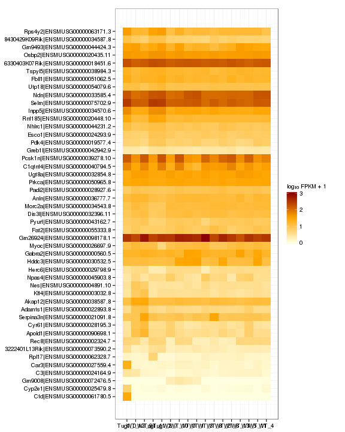

Isoform foldchange heatmap by isoform:

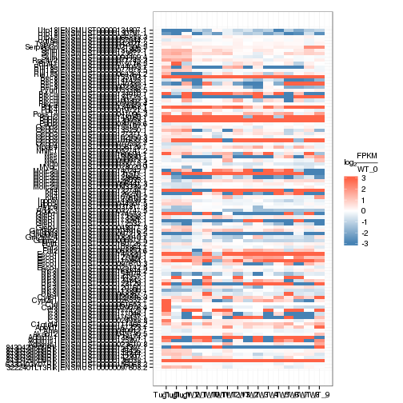

### Differential Splicing between conditions

(eval false for first pass)

Per condition differences in isoforms (Does gene have diff piechart between conditions?)

# Gene/Pathway Analysis

## GSEA

[output not shown]

[figure not shown]

[output not shown]

[figure not shown]

[output not shown]

[figure not shown]

[figure not shown]

## GO enrichment

Cluster profiler used to call enichments of significantly differentially regulated genes that map to Entrez IDs.

[output not shown]

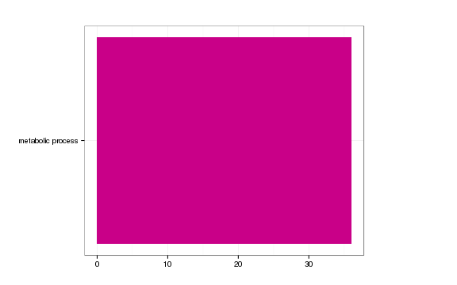

[output not shown]

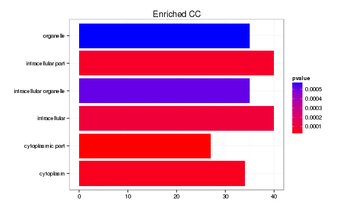

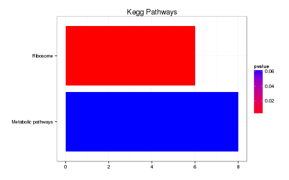

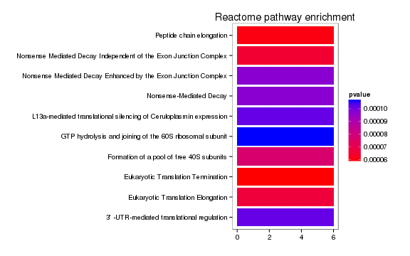

# Cis vs Trans (locally)

The pvalue for 7 genes significantly regulated in a region this size is: 0.004

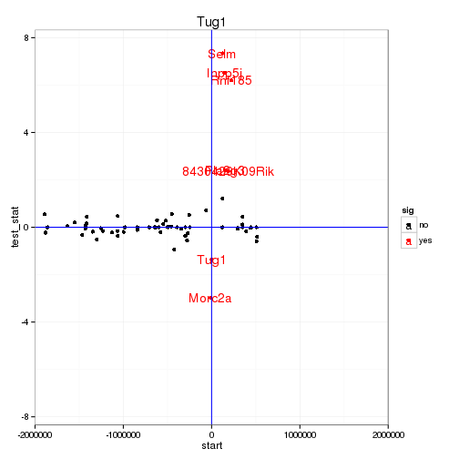

# Notes

## Samples used are:

|  | 10 |
| --- | --- |
| 1 | JR729 |
| 2 | JR728 |
| 3 | JR796 |
| 4 | JR797 |
| 5 | JR740 |
| 6 | JR800 |
| 7 | JR827 |
| 8 | JR778 |
| 9 | JR734 |
| 10 | JR802 |
| 11 | JR803 |
| 12 | JR735 |
| 13 | JR785 |
| 14 | JR781 |
| 15 | JR828 |
| 16 | JR745 |
| 17 | JR807 |

## Replicates

|  | file | sample_name | replicate | rep_name | total_mass | norm_mass | internal_scale | external_scale |
| --- | --- | --- | --- | --- | --- | --- | --- | --- |
| 1 | /n/rinn_data1/seq/lgoff/Projects/BrainMap/data/quants/JR729/abundances.cxb | WT | 0 | WT_0 | 26338300.00 | 34386400.00 | 0.76 | 1.00 |
| 2 | /n/rinn_data1/seq/lgoff/Projects/BrainMap/data/quants/JR728/abundances.cxb | WT | 1 | WT_1 | 20332100.00 | 34386400.00 | 0.59 | 1.00 |
| 3 | /n/rinn_data1/seq/lgoff/Projects/BrainMap/data/quants/JR796/abundances.cxb | WT | 2 | WT_2 | 34093300.00 | 34386400.00 | 0.99 | 1.00 |
| 4 | /n/rinn_data1/seq/lgoff/Projects/BrainMap/data/quants/JR797/abundances.cxb | WT | 3 | WT_3 | 28111900.00 | 34386400.00 | 0.81 | 1.00 |
| 5 | /n/rinn_data1/seq/lgoff/Projects/BrainMap/data/quants/JR740/abundances.cxb | WT | 4 | WT_4 | 35813300.00 | 34386400.00 | 1.04 | 1.00 |
| 6 | /n/rinn_data1/seq/lgoff/Projects/BrainMap/data/quants/JR800/abundances.cxb | WT | 5 | WT_5 | 37017800.00 | 34386400.00 | 1.08 | 1.00 |
| 7 | /n/rinn_data1/seq/lgoff/Projects/BrainMap/data/quants/JR827/abundances.cxb | WT | 6 | WT_6 | 27790600.00 | 34386400.00 | 0.81 | 1.00 |
| 8 | /n/rinn_data1/seq/lgoff/Projects/BrainMap/data/quants/JR778/abundances.cxb | WT | 7 | WT_7 | 39549100.00 | 34386400.00 | 1.16 | 1.00 |
| 9 | /n/rinn_data1/seq/lgoff/Projects/BrainMap/data/quants/JR734/abundances.cxb | WT | 8 | WT_8 | 34485000.00 | 34386400.00 | 1.02 | 1.00 |
| 10 | /n/rinn_data1/seq/lgoff/Projects/BrainMap/data/quants/JR802/abundances.cxb | WT | 9 | WT_9 | 45472800.00 | 34386400.00 | 1.31 | 1.00 |
| 11 | /n/rinn_data1/seq/lgoff/Projects/BrainMap/data/quants/JR803/abundances.cxb | WT | 10 | WT_10 | 52136700.00 | 34386400.00 | 1.52 | 1.00 |
| 12 | /n/rinn_data1/seq/lgoff/Projects/BrainMap/data/quants/JR735/abundances.cxb | WT | 11 | WT_11 | 34999600.00 | 34386400.00 | 1.02 | 1.00 |
| 13 | /n/rinn_data1/seq/lgoff/Projects/BrainMap/data/quants/JR785/abundances.cxb | WT | 12 | WT_12 | 34180700.00 | 34386400.00 | 0.98 | 1.00 |
| 14 | /n/rinn_data1/seq/lgoff/Projects/BrainMap/data/quants/JR781/abundances.cxb | WT | 13 | WT_13 | 41544600.00 | 34386400.00 | 1.22 | 1.00 |
| 15 | /n/rinn_data1/seq/lgoff/Projects/BrainMap/data/quants/JR828/abundances.cxb | Tug1 | 0 | Tug1_0 | 38779500.00 | 34386400.00 | 1.13 | 1.00 |
| 16 | /n/rinn_data1/seq/lgoff/Projects/BrainMap/data/quants/JR745/abundances.cxb | Tug1 | 1 | Tug1_1 | 38096600.00 | 34386400.00 | 1.11 | 1.00 |
| 17 | /n/rinn_data1/seq/lgoff/Projects/BrainMap/data/quants/JR807/abundances.cxb | Tug1 | 2 | Tug1_2 | 29983700.00 | 34386400.00 | 0.87 | 1.00 |

## Run Info

[output not shown]